# Mortality and the COVID-19 Pandemic

Bowie Chuang, Jessica Chen, Saiteja Kambhampati, Nicholas Tan, Nicholas Qin Wang, Hank Wang

8/10/2021

```r
library(ggplot2)
library(dplyr)
#file.choose()
covid = read.csv("/Users/nicholastan/Downloads/covid.csv")
```

## Introduction:

The sudden, disruptive spread of the COVID-19 pandemic challenged the response capacities of organizations and governments both locally and worldwide as it distressed countless populations. From social isolation under stay at home orders to mask mandates and unemployment, the pandemic has had an undeniable impact on society at large, but arguably the most significant consequence has been the tragic loss of life.

Reflecting on this, our group was particularly interested in pandemic-induced mortality and its relation to societal factors, population demographics, and statewide-policy.

During our initial brainstorming discussion we came up with several potential vectors for investigation:

-How do policies on face covering relate to mortality rates?

-Do more restrictive mask mandates correlate with a lower mortality rate?

-Has there been an increase in depression rate during the pandemic?

-What does the interplay between depression rates and mortality rates look like?

-What are some healthcare and societal factors that might influence mortality rates?

-Does air quality affect mortality rates? -Are ICU bed counts associated with mortality?

-How is insurance related to mortality rates if at all?

-Has government policy on medicaid been associated with mortality rates?

-Do elderly population percentages track with mortality rates?

-How are different reopening strategies related to mortality rates?

## Exploratory Data Analysis:

### Hank: Effectiveness of Face Coverings

Despite the announcements made by the US Centers for Disease Control and National Institute of Health, individual states had their own mask requirements, ranging from requirements requiring the wearing of face coverings in public, to a more moderate policy of only requiring specific employees to wear masks, to a more flexible policy of letting local officials to make the decision with regards to their mask mandate policy. Masks or face coverings were encouraged by Health Organizations for the general public in order to reduce the spread of the virus. The theory was that the masks would serve as a protective shield in public, as the virus would not be able to pass through the mask’s fabric, thus making it more difficult for the virus to penetrate into the individual’s facial orifices and into their body system.

The data structures seen below are boxplots that compare the differing mortality rates in the Month of June and the Month of October, based on the different face covering mandates adopted and administered by the state government.

The data was derived by first filtering the data using the dplyr function filter, based on the varying options available for face covering policy. Then, using the boxplot from ggplot2, the data was organized into two individual box plots, with two from June and two from October, with 5 different categories available for the different types and combinations of policies enacted. This ranged from “Required for General Public”, to Required for Certain Employees, to No Mandate Present, represented by a blank “-”, and Certain Hybrid Policies and policies that gave local officials discretion over the mask mandate.

In looking at the COVID 19 Mortality in June, we see quite a large difference in mortality rates, with the Mandate of Requiring masks for the general public and the hybrid policies having the highest mortality rates, while the states with no mask mandates had the lowest mortality rates. This however, may not nullify the conclusions made using the October 2020 data for mortality. Because June 2020 comes before October 2020 chronologically, the states with no mask mandates may not have yet been exposed to COVID sufficiently for accurate mortality rates to be determined. That is, there might be confounding factors such as population density that implicates mortality in addition to the potential variable of mask wearing mandates.

We can conclude that as time progresses and more accurate data is obtained,state mask mandates with the policy requiring masks for the general public were observed to have the lowest mortality rate of states that had mask mandates, while the states that did not have mandates had a high mortality rate. However this data might not be definitively conclusive due to the many confounding variables such as population density and actual adherence of residents wearing masks to their mask mandates.

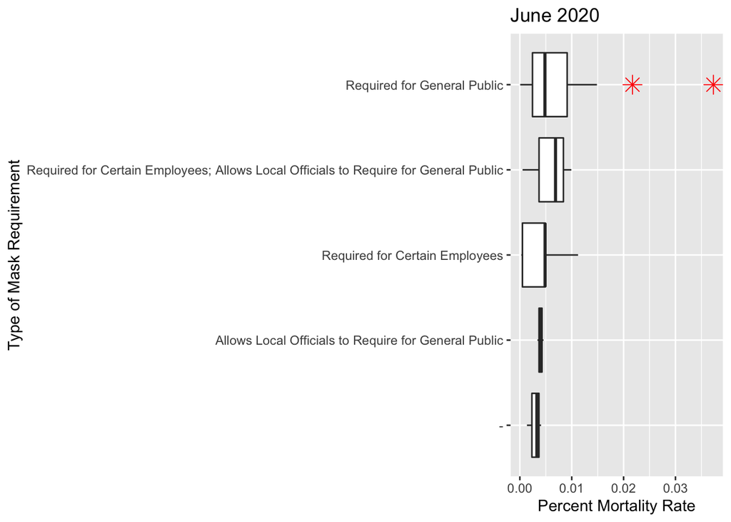

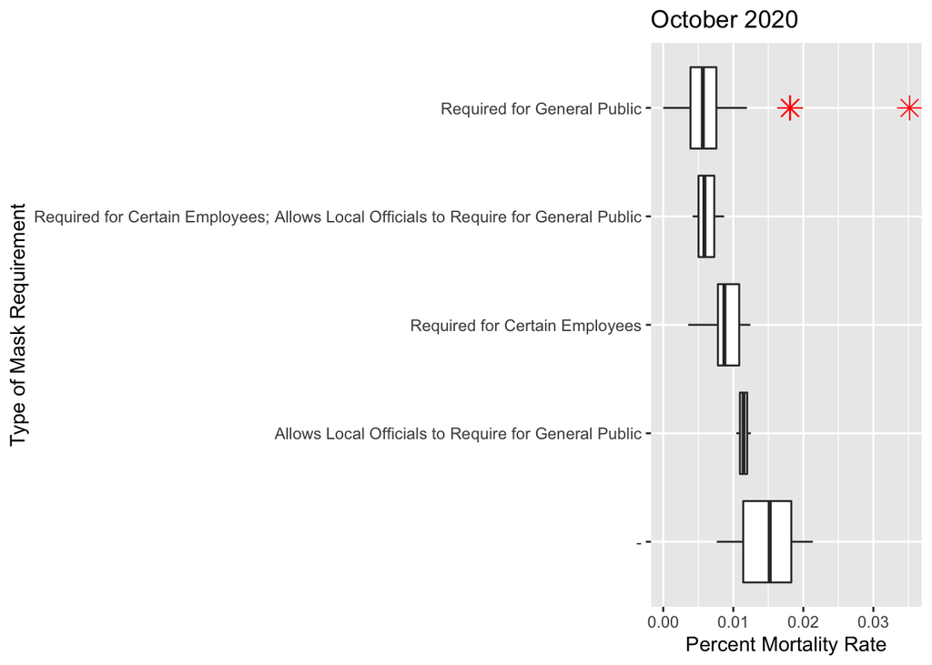

### Nicholas Tan: Depression and The Covid-19 Pandemic

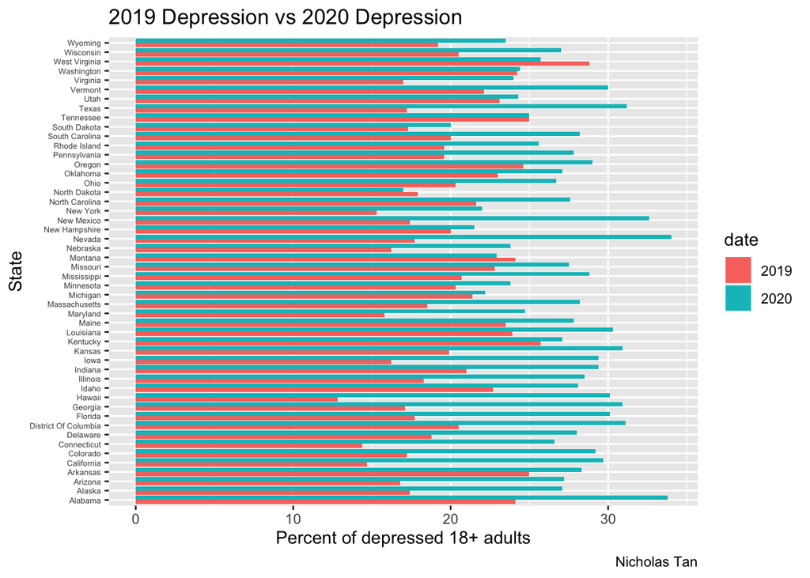

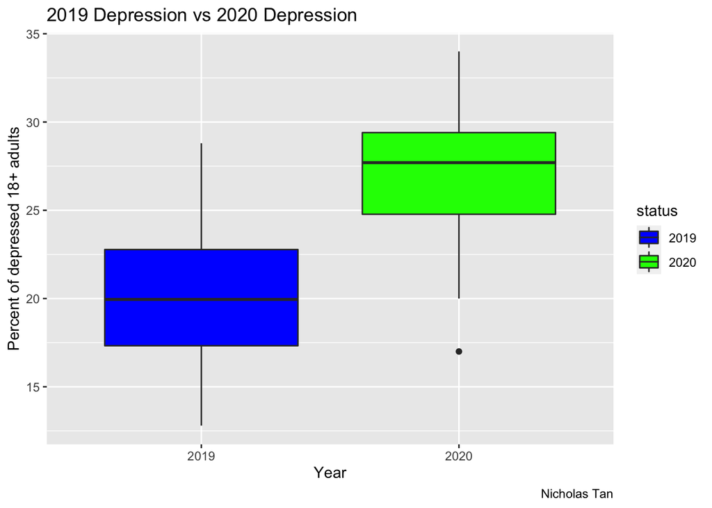

```
##                   statistic  value
## 1 2019 Mean Depression Rate 19.978
## 2 2020 Mean Depression Rate 27.194
```

From social distancing to mass unemployment, societal changes brought by the advent of the covid-19 pandemic affected people’s mental health. The CDC found “Symptoms of anxiety disorder and depressive disorder increased considerably in the United States during April–June of 2020, compared with the same period in 2019.” First, we show a bar graph with the percent of those depressed in each state for 2019 and 2020. We see a trend that the 2020 percentages appear larger than the 2019 percentages and further elucidate this in the box plot. In the box plot we look at the same surveyed data on the prevalence of depression among adults from Oct 28th to Nov 9th, 2020 and compare it to 2019 data on depression. There is one categorical variable for the year on the x axis and one quantitative variable for the average percentage of depressed adults among states with available data in both 2019 and 2020. We see that the median, highest, and lowest state depression rates are all larger in 2020 than in 2019. From the summary statistics, we find that average depression rates among states appeared to increase from a 2019 average of 19.98% to a 2020 average of 27.19%. This makes us question the relationship between the covid-19 pandemic and depression rates.

source: https://www.cdc.gov/mmwr/volumes/69/wr/mm6932a1.htm

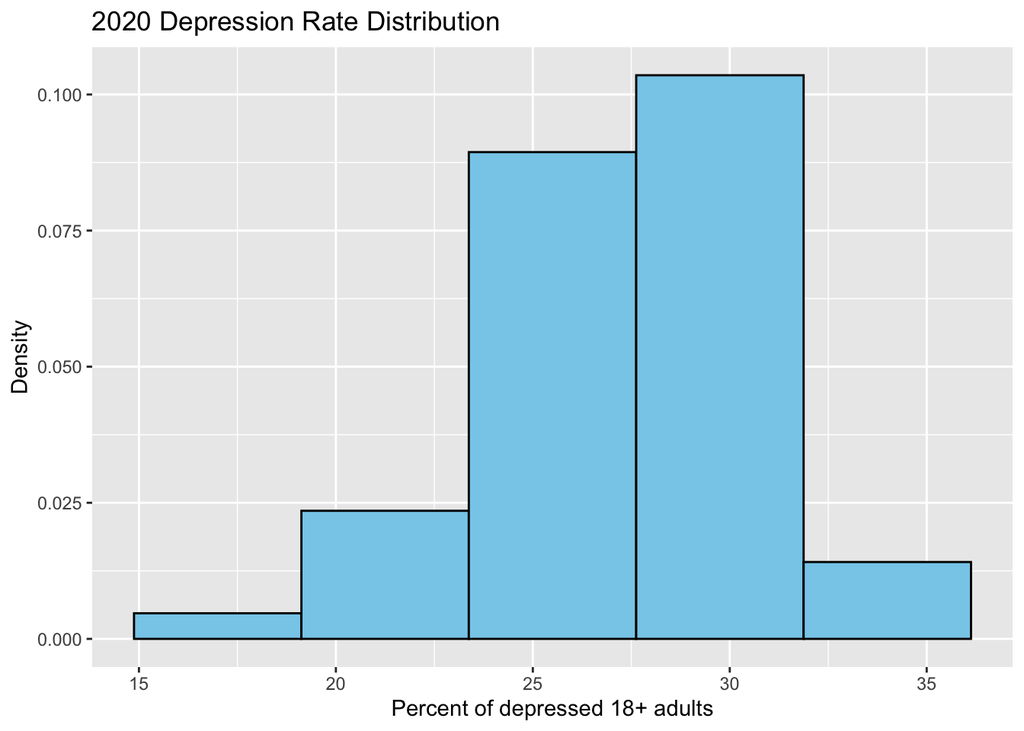

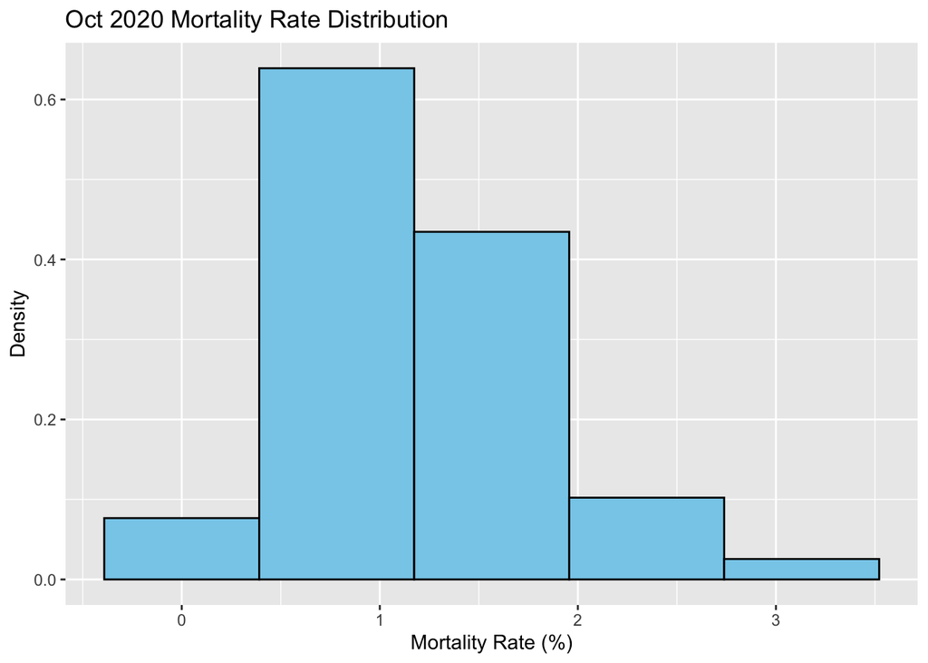

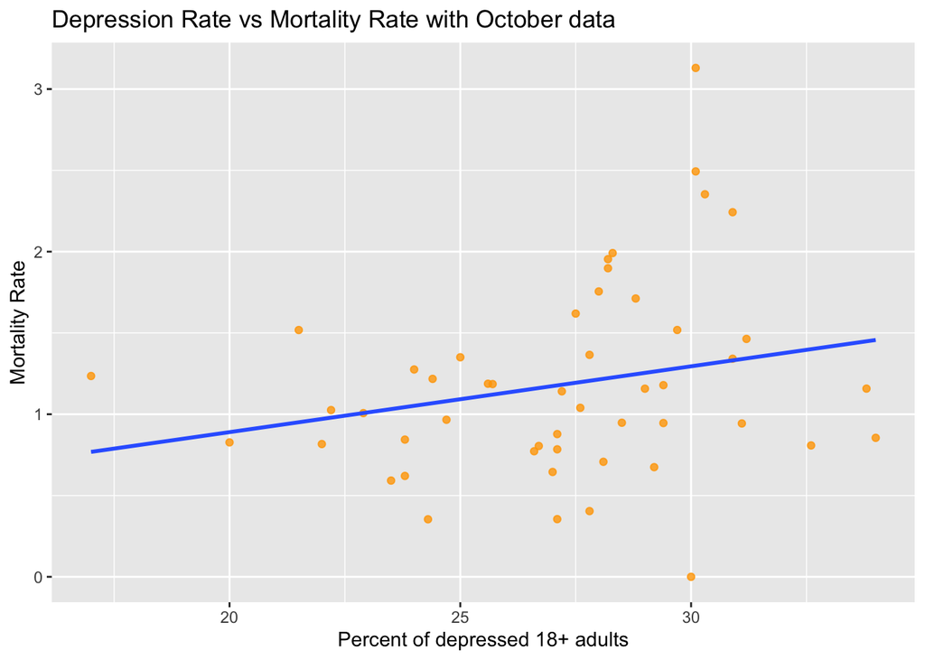

```
##        summary.statistics        value
## 1      sd depression rate  3.416571966
## 2       sd mortality rate  0.005875373
## 3    mean depression rate 27.194000000
## 4     mean mortality rate  0.011811569
## 5 highest depression rate 34.000000000
## 6  lowest depression rate 17.000000000
## 7      highest death rate  0.031298905
## 8       lowest death rate  0.000000000
## 9                       r  0.235444916
```

With many losing loved ones during the pandemic, we suspect there may be an association between mortality rates and depression rates in states. We treat depression rate and mortality rate as continuous, quantitative variables and plot histograms of both. The covid-19 mortality rate is calculated by the number of deaths in October over the total number of cases in October. Because we have a sample of convenience, there may very well be bias for whichever month is selected, but given we only have 2 months of data to choose from, June or October, we felt this was an adequate approach. We also note that both do not follow the normal distribution particularly well and that this may hinder the efficacy of linear regression techniques used later. Nevertheless, we graph a scatter plot with the rates of depression among states on the x axis and the mortality rates among states on the y axis. We calculate a slightly positive correlation of about .24. While this does not prove causation between the effect of mortality rates on depression rates, it does suggest the possibility of a minimal association between the depression rates and mortality rates in states. We highlight this as an area for further data analysis but note that the CDC did find “The coronavirus disease 2019 (COVID-19) pandemic has been associated with mental health challenges related to the morbidity and mortality caused by the disease.”

### Bowie: Number of ICU Beds and Mortality Bowie

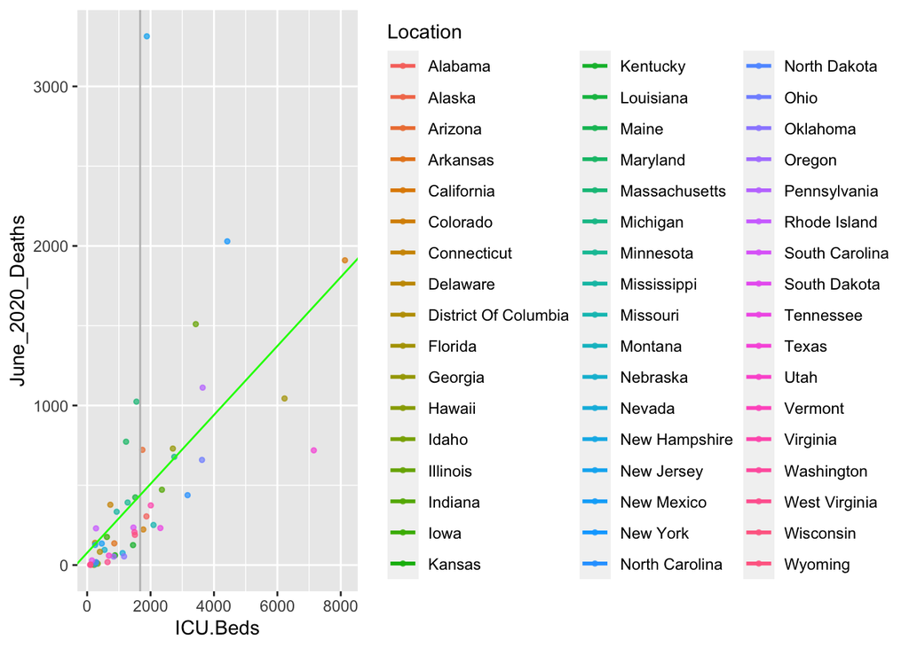

ICU beds, known as intensive care unit beds, are usually used when the patients have emergency issues with their life. In this case, we decided to see the correlation between the number of ICU beds and the number of death cases. According to the scatter plot, although there are a few outliers, we can tell that there’s a strong positive correlation between numbers of deaths and ICU beds. Although the graph doesn’t support my prediction that the number of ICU beds can reduce the number of death caes, the number of ICU beds for each state is consistent with the proportion of the number of deaths. Moreover, It is easy to spot the outliers when all states are labeled in different colors, and thus fix disproportionate. This could be supplying more ICU beds to specific states that need more help.

### Bowie: Medicaid Expansion and Mortality

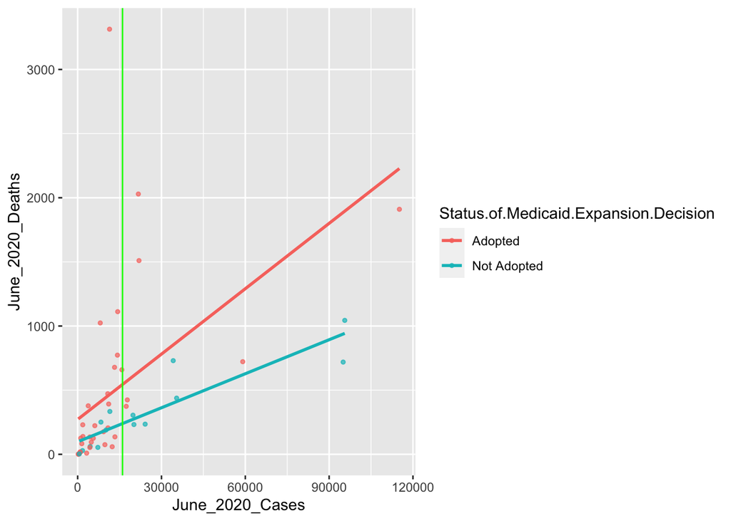

According to this graph about the relationship between the number of cases vs the number of deaths amid each state’s status of medicaid expansion, it illustrates that states not adopting medicaid tend to have less people die from Covid. This graph counters what we expect, which is states adopting medicaid should have lower death rates. When we take a closer look at each state that didn’t adopt medicaid, we can tell that these are states that have a more conservative stance. In fact, the states who have recorded more death cases are populous states such as Florida and Texas, which have a population greater than other states. In the end, medicaid can’t really make a huge influence on the number of death cases, but state populations can perhaps make some impact because it is easier to spread from person to person if the population is denser.

### Bowie: Consequences of DIfferent Reopening Statuses on Cases and Deaths

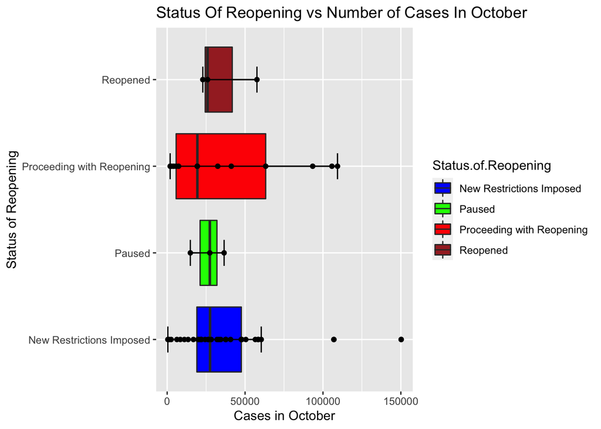

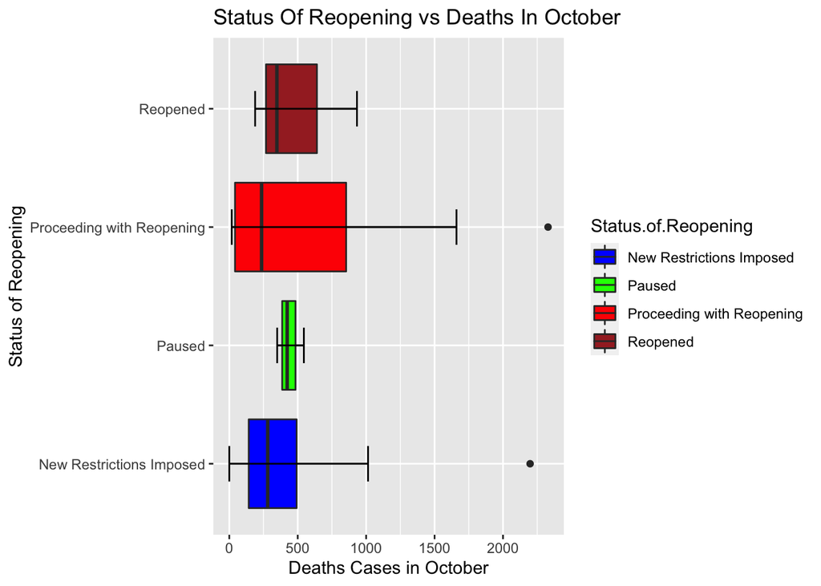

```
##     reopened
##  Min.   :189.0
##  1st Qu.:268.5
##  Median :348.0
##  Mean   :490.0
##  3rd Qu.:640.5
##  Max.   :933.0
```

```
##       pwr
##  Min.   :  18.0
##  1st Qu.:  42.0
##  Median : 236.0
##  Mean   : 575.8
##  3rd Qu.: 854.0
##  Max.   :2329.0
```

```
##      pause
##  Min.   :350.0
##  1st Qu.:386.5
##  Median :423.0
##  Mean   :439.3
##  3rd Qu.:484.0
##  Max.   :545.0
```

```
##       nri
##  Min.   :   0.0
##  1st Qu.: 142.0
##  Median : 281.0
##  Mean   : 370.7
##  3rd Qu.: 492.2
##  Max.   :2198.0
```

First, we took numbers from October, not June, because the status of reopening was decided in November, 2020; therefore, I believe it best to take a close look at the number of cases and deaths in October. According to the two boxplot, we can tell that states don’t really make decisions based on numbers of cases and deaths. Each status has states that recorded over ten thousands of cases. The only trend we can obtain from the boxplot of cases vs status of reopening is that the states that paused or imposed new restrictions have a higher median than the other two status.

### Nicholas Wang

Because COVID-19 is an airborne virus that is primarily transmitted through airborne droplets and viral particles, there could be a relationship between the quality of air and how contagious COVID is. The average Air Quality Index of 2020 is chosen to be compared with the percentage of COVID cases in each state’s population, and the percentage of deaths for each state’s number of COVID cases. The number of COVID cases and deaths are chosen from October 2020 because at this time, 46 out of 52 states already have face cover mandates, and all states, except South Dakota, have already enforced business closures, restaurant limits, and bans on large gatherings. This reduces the number of confounding factors that may affect the conceived correlation between AQI and COVID cases/deaths. According to a study done by Int J Environ Res Public Health, atmospheric matter in the air could increase the susceptibility of patients to COVID as it could create a suitable environment for transporting the virus at further distances. There is thus a suggested correlation between air quality and the rate of infections, where as the air quality worsens, the rate of COVID cases should increase.

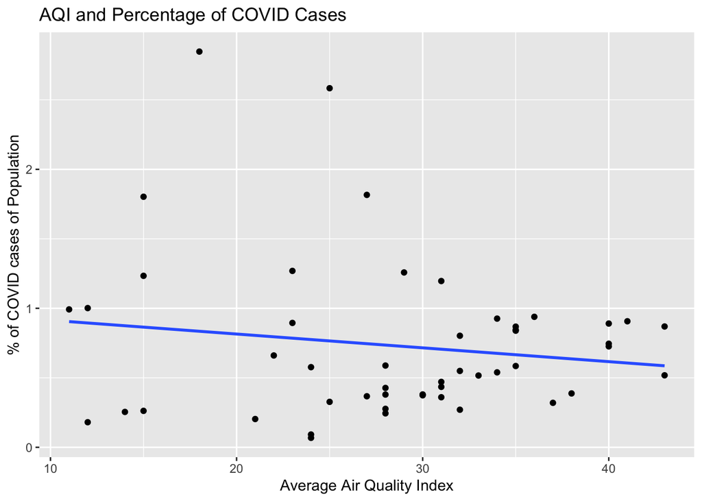

```
##
## Call:
## lm(formula = COVID_rate ~ AQI, data = AQIcases)
##
## Residuals:
##     Min      1Q  Median      3Q     Max
## -0.7140 -0.3435 -0.1366  0.2261  2.0124
##
## Coefficients:
##              Estimate Std. Error t value Pr(>|t|)
## (Intercept)  1.013732   0.283534   3.575 0.000798 ***
## AQI         -0.009934   0.009546  -1.041 0.303159
## ---
## Signif. codes:  0 '***' 0.001 '**' 0.01 '*' 0.05 '.' 0.1 ' ' 1
##
## Residual standard error: 0.563 on 49 degrees of freedom
## Multiple R-squared:  0.02162,    Adjusted R-squared:  0.001655
## F-statistic: 1.083 on 1 and 49 DF,  p-value: 0.3032
```

According to the study done by Int J Environ Res Public Health, atmospheric particulate matter in the air can also induce inflammations in the lungs that could increase the severity of COVID-19 patient symptoms. Since poor air quality could increase the severity of symptoms, which could lead to death, the relationship between the AQI and the death rate of COVID cases is tested.

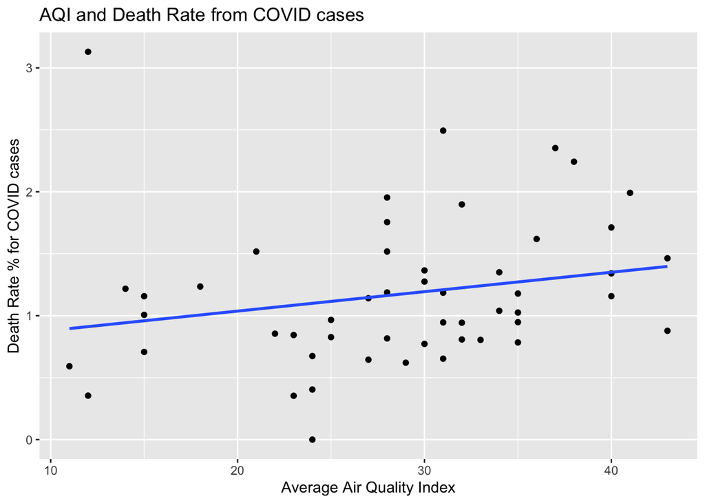

```
##
## Call:
## lm(formula = Death_rate ~ AQI, data = AQIdeath)
##
## Residuals:
##     Min      1Q  Median      3Q     Max
## -1.0998 -0.3815 -0.1494  0.2519  2.2181
##
## Coefficients:
##             Estimate Std. Error t value Pr(>|t|)
## (Intercept) 0.723777   0.293798   2.464   0.0173 *
## AQI         0.015669   0.009892   1.584   0.1196
## ---
## Signif. codes:  0 '***' 0.001 '**' 0.01 '*' 0.05 '.' 0.1 ' ' 1
##
## Residual standard error: 0.5834 on 49 degrees of freedom
## Multiple R-squared:  0.04871,    Adjusted R-squared:  0.0293
## F-statistic: 2.509 on 1 and 49 DF,  p-value: 0.1196
```

According to the scatter plot and the regression line, there is a positive correlation between the AQI and death rates where death rates increase as AQI increases. This suggests that more polluted air is correlated to more COVID deaths. The correlation coefficient is 0.22, a weak positive correlation. The regression line supports the aforementioned hypothesis so far. The hypothesis test yields a p-value of 0.1196, or 11.96%. The p value is higher than 5%, and although we cannot reject the null hypothesis entirely, there is a good chance that the regression line could be due to chance occurrence.

### Jessica: The Elderly Population and Covid Deaths

Do states that have more people aged 65 or above per capita have more Covid deaths per capita in a month? The CDC states that older adults have a higher Covid-19 mortality rate (COVID-19 Risks and Vaccine Information for Older Adults). Therefore, we hypothesize that states that have a higher number of people aged 65 or older per capita would have more deaths Covid per capita in a month.

The raw number of people aged 65 or above in each state was divided by the total population in each state to give the number of people aged 65 or above per capita.The raw number of Covid related deaths in a month in each state was divded by the total population in each state to give the number of Covid related deaths per capita. Converting to “per capita” allows the variables to be compared more fairly and accurately, because it accounts for a confounding factor - population. A state with a larger population and thereby a higher number of people aged 65 or above may have more covid related deaths in a month not because of its larger elderly population, but its larger population in general. We will examine the number of deaths per capita in the months October 2020, and June 2020.

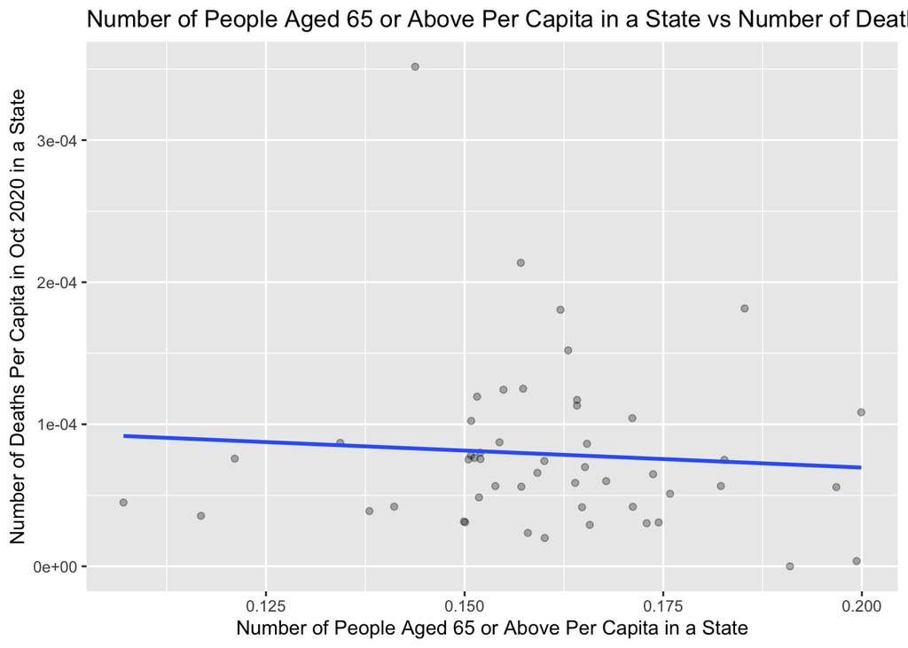

```
## [1] -0.07546624
```

```
## [1] -0.000239169
```

The correlation coefficient shows a weak negative correlation between the number of people aged 65 or above per capita in a state and the number of deaths per capita in October 2020 in a state. The slope of the regression line suggests that on average, states with a higher number of people aged 65 or above per capita had a lower number of deaths per capita in October 2020.

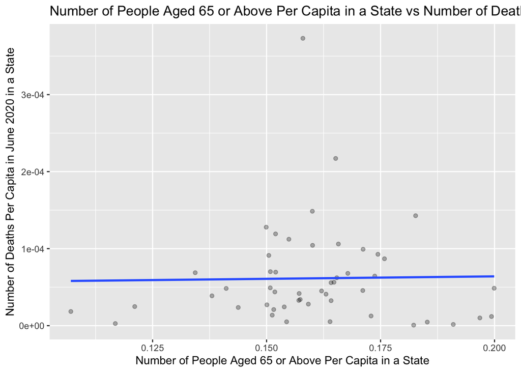

```
## [1] 0.01880723
```

```
## [1] 6.385268e-05
```

### Saiteja: Uninsured and COVID-19

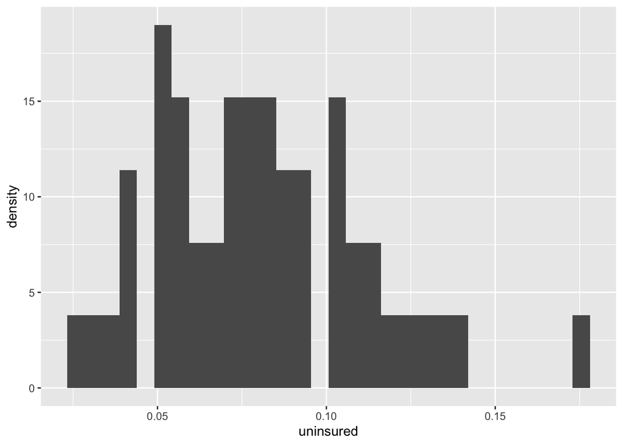

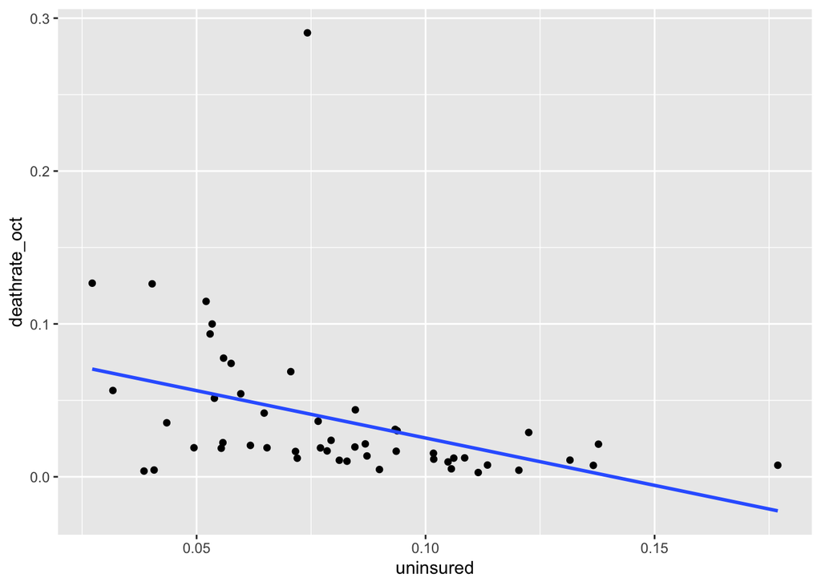

Source: https://familiesusa.org/wp-content/uploads/2021/03/2021-37_Loss-of-Lives_Report_AnalysisStyleB_Final.pdf

## Data Analysis and Inference:

### Hypothesis Test: Further analysis on mask mandates for the general public

```
##                                           statistics         value
## 1     Mean mortality rate for RGP with June data (%)  4.5332083902
## 2 Mean mortality rate for non-RGP with June data (%)  1.3914651094
## 3      Mean mortality rate for RGP with Oct data (%)  1.1388101512
## 4  Mean mortality rate for non-RGP with Oct data (%)  1.2643266406
## 5                         z statistic with June data  3.5119841961
## 6                             p value with June data  0.0002223872
## 7                          z statistic with Oct data -0.6191183564
## 8                              p value with Oct data  0.2679191957
```

In this section we conduct a two sample z-test comparing the mortality rate between states that had a mask mandate “Required for General Public” (RGP) and all other states with less restrictive mask mandate policies.

We treat the states as samples and note that while the group for states with less restrictive mask policies is below 25 in size, the total combined sample size from both groups is above 25, so a two sample z-test, rather than t-test, can still be performed. Although, we also recognize this is not a simple random sample and that we only have mortality rate data for June and October.

Null Hypothesis: The difference in mortality rates between states with general public mask mandates and states with less restrictive mask mandates is due to chance. The mean mortality rate is the same for “Required for General Public” (RGP) mandated states and non-RGP mandated states.

Alternative Hypothesis: The difference in mortality rates between states with general public mask mandates and states with less restrictive mask mandates is not due to chance. For June, the mean mortality rate for states with RGP mandates, 4.5%, is larger than the mortality rate for states without RGP mandates, 1.4%. For October, the mean mortality rate for states with RGP mandates, 1.1%, is smaller than the mortality rate for states without RGP mandates, 1.3%.

For June, we get a z statistic of about 3.51 and a p value of about .02%. We reject the null hypothesis at the 1% level. The difference in mortality rates between states with “Required for General Public” (RGP) and states non-RGP mandates is not due to chance. It looks like states with RGP mandates have a higher mortality rate than states with non-RGP mandates.

For October, we get a z statistic of about -.62 and a p value of about 26.8%. We fail to reject the null hypothesis. The difference in mortality rates between states with RGP mandates and states with non-RGP mandates is due to chance. The mean mortality rate is the same for RGP mandated states and non-RGP mandated states.

### 2020 Depression and Covid-19 Continued:

First, we further analyze the increased rate of depression in 2019 and 2020 with a two sample z test. 2019 states and 2020 states with data available for depression rates are treated as our two sample groups.

Null Hypothesis: The mean of depressed population percentages for 2019 states is the same as in 2020. The difference between the two percentages are due to chance.

Alternative Hypothesis: The mean of depressed population percentages increased from 2019 to 2020. The difference is not due to chance.

We get a z statistic of about -10.62 and a p value of 1.24e-26. We reject the null hypothesis at the 0% level. The difference between 2019 and 2020 is not due to chance and the depression rate increased.

```
##     statistic         value
## 1 z statistic -1.061703e+01
## 2     p value  1.241703e-26
```

Following these results we continue to check if there is a relation between Covid-19 mortality rates and this observed increase in depression rates.

From the previous section relating depression rates and covid 19 mortality rates, we observed a slightly positive correlation of .24 between October 2020 mortality rates and 2020 depression rates taken from October 28th to November 9th 2020.

Here we provide a scatter plot for the June 2020 mortality rates and depression rates and then graph the regression line. We note a slightly negative correlation of -.19. This could suggest an association between higher mortality rates and lower depression rates, the opposite of what was found for the October mortality rate data.

Next, we graph the residuals for the October and June regression plots between mortality rates and depression rates. In both plots we don’t notice any strong patterns so it seems regression was suitable and there wasn’t any significant nonlinearity.

Finally we conduct a hypothesis test for the slope of the regression lines to see if the relationship between mortality rates in June or October and 2020 depression rates can be explained by chance.

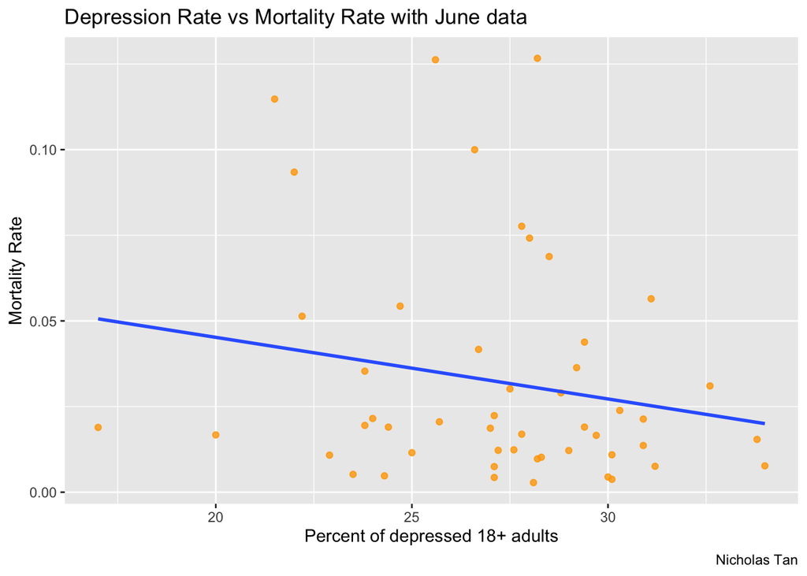

```
##
## Call:
## lm(formula = death.rate ~ depressed, data = depression.vs.deaths.oct.df)
##
## Residuals:
##        Min         1Q     Median         3Q        Max
## -0.0129477 -0.0039102 -0.0007735  0.0025246  0.0183107
##
## Coefficients:
##              Estimate Std. Error t value Pr(>|t|)
## (Intercept) 0.0008011  0.0066117   0.121   0.9041
## depressed   0.0004049  0.0002412   1.678   0.0998 .
## ---
## Signif. codes:  0 '***' 0.001 '**' 0.01 '*' 0.05 '.' 0.1 ' ' 1
##
## Residual standard error: 0.005828 on 48 degrees of freedom
## Multiple R-squared:  0.05543,    Adjusted R-squared:  0.03576
## F-statistic: 2.817 on 1 and 48 DF,  p-value: 0.09977
```

```
##
## Call:
## lm(formula = death.rate ~ depressed, data = depression.vs.deaths.june.df)
##
## Residuals:
##       Min        1Q    Median        3Q       Max
## -0.033698 -0.020061 -0.012147  0.008516  0.096202
##
## Coefficients:
##              Estimate Std. Error t value Pr(>|t|)
## (Intercept)  0.081176   0.036871   2.202   0.0325 *
## depressed   -0.001799   0.001345  -1.337   0.1875
## ---
## Signif. codes:  0 '***' 0.001 '**' 0.01 '*' 0.05 '.' 0.1 ' ' 1
##
## Residual standard error: 0.0325 on 48 degrees of freedom
## Multiple R-squared:  0.03591,    Adjusted R-squared:  0.01582
## F-statistic: 1.788 on 1 and 48 DF,  p-value: 0.1875
```

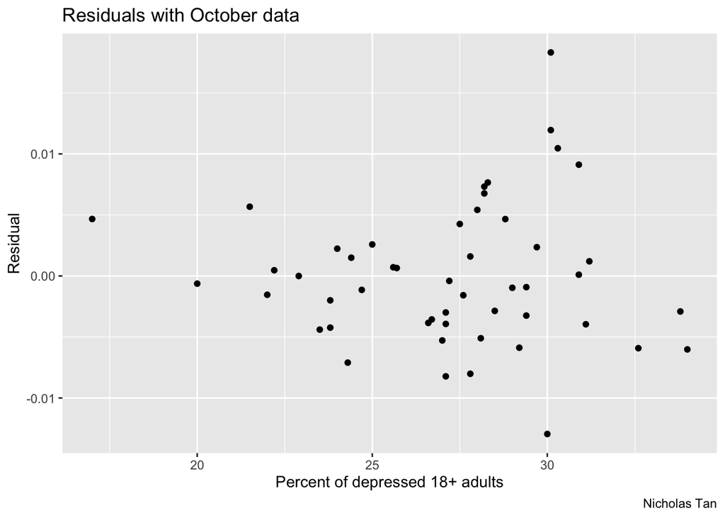

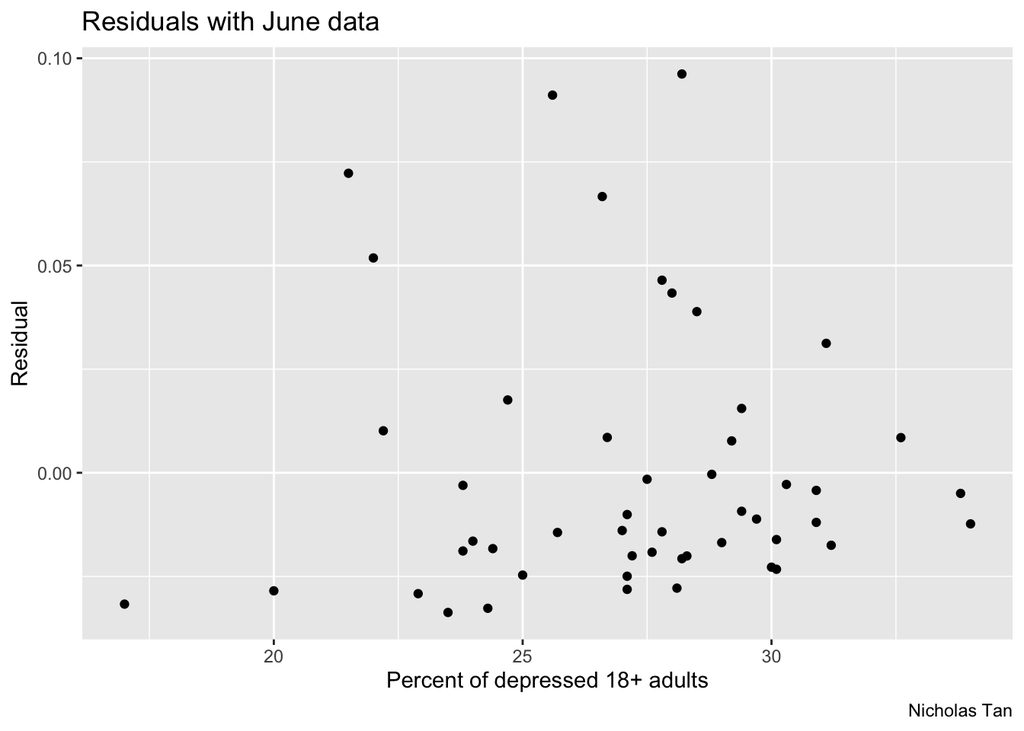

```
##                             statistics       values
## 1           SD for 2020 deprssion rate  3.416571966
## 2       SD for Oct 2020 moratlity rate  0.005875373
## 3      Average for 2020 deprssion rate 27.194000000
## 4  Average for Oct 2020 moratlity rate  0.011811569
## 5      SD for June 2020 moratlity rate  0.032430767
## 6 Average for June 2020 moratlity rate  0.032261763
```

```
##                         statistics        values
## 1            October r correlation  0.2354449158
## 2               June r correlation -0.1894940874
## 3 October slope of regression line  0.0004048873
## 4    June slope of regression line -0.0017987148
## 5              October t statistic  1.6783937433
## 6                  October p value  0.0997702290
## 7                 June t statistic -1.3370789294
## 8                     June p value  0.1874992482
```

Null Hypothesis: The relationship or non-zero correlation between mortality rates in June/October and 2020 depression rates can be explained by chance.

Alternative Hypothesis: For October, the relationship between mortality rates and depression rates have a slight positive correlation and are not due to chance. For June, the relationship between mortality rates and depression rates have a slight negative correlation and are not due to chance.

In calculating the t statistics and p values, we make the manual calculations and also check them against the summary statistics given by the lm function.

For October, we get a t statistic of about 1.68 and a p value of about 10.0%. We fail to reject the null, the slightly positive correlation we saw earlier could be explained by chance.

For June, we get a t statistic of about -1.34 and a p value of about 18.8%. We fail to reject the null, the slightly negative correlation from before could be explained by chance.

## Conclusion

Continuing the theme ofhow governmental policy is associated with mortality rates, our first detailed data analysis investigated how face covering policy affected mortality rates. After conducting a two sample z test, data from June rejected the null hypothesis and found that states with “Required for General Public” mask mandates fared worse in terms of mortality rates than states without “Required for General Public” mandates. Conversely, we failed to reject the null hypothesis for data from October finding that the difference between mortality rates was not significant and could be explained by chance.

We observe that this z test does not generate any casual relationship between mask policy and mortality rates and that there could be many confounding factors that explain the relationship. For example, the time that mask mandates were implemented and when mortality rates were calculated may explain the relationship, or the demographic makeup of different states with different population densities and varying methods of enforcing requirements could confound the results between face covering policy and mortality rates. We also notice that a two sample z test may not be practical here given that we don’t have a simple random sample, but rather a sample of convenience of states compared to June and October mortality rates. These limitations may explain why we had contradictory results between June and October mortality rate data.

Attempting to further investigate the relationship of societal and demographic factors with mortality rates, we conducted a hypothesis test and regression analysis on depression rates and mortality rates.

First we checked to see if the increased rates of depression from 2019 to 2020 were due to chance with a two sample z test. We rejected the null and concluded that depression rates did increase. We feel more comfortable about this z test given that the underlying statewide depression rate data was provided from a sample that more closely resembled a simple random sample.

Again, we note that our regression techniques may not be completely viable given that depression rates and death rates from the covid data are not particularly normally distributed. We also note that we can’t exactly treat the covid data as a box model given that we don’t have simple random samples from larger populations.

We also can’t make any causal inferences on mortality rates contributing to depression rates during the COVID-19 pandemic or pandemics at large. There are also a plethora of confounding factors that could explain the increased depression rates – social isolation, unemployment, or even social media usage trends could all be prime suspects.

All in all, we weren’t left with very much definitive analysis when investigating the mortality rates during the COVID-19 pandemic and its relationship with governmental policy, societal factors, and population demographics. We thought this showcased how intricate and multifaceted discussion pertaining to mortality rates is and how difficult it can be to find simple casual links among a complex, interwoven web of data.

## References

“COVID-19 Risks and Vaccine Information for Older Adults.” Centers for Disease Control and Prevention, Centers for Disease Control and Prevention, 2 Aug. 2021, www.cdc.gov/coronavirus/2019-ncov/need-extra-precautions/older-adults.html.

Czeisler MÉ , Lane RI, Petrosky E, et al. Mental Health, Substance Use, and Suicidal Ideation During the COVID-19 Pandemic — United States, June 24–30, 2020. MMWR Morb Mortal Wkly Rep 2020;69:1049–1057. DOI: http://dx.doi.org/10.15585/mmwr.mm6932a1external icon

Dorn, Stan, and Rebecca Gordon. “The Catastrophic Cost of Uninsurance: COVID-19 Cases and Deaths Closely Tied to America’s Health Coverage Gaps.” Families USA, familiesusa.org/wp-content/uploads/2021/03/2021-37_Loss-of-Lives_Report_AnalysisStyleB_Final.pdf.

Nirmita Panchal, R. K., & 2021, F. (2021, July 20). The implications of Covid-19 for mental health and substance use. KFF. https://www.kff.org/coronavirus-covid-19/issue-brief/the-implications-of-covid-19-for-mental-health-and-substance-use/.